# 04. Model_Explainability_Conclusions

### Importamos librerías

```python
import pandas as pd
import numpy as np
import seaborn as sns
import matplotlib.pyplot as plt
import plotly.express as px
import scipy.stats as ss
import sklearn
import category_encoders as ce
from boruta import BorutaPy
from sklearn.model_selection import cross_val_score, train_test_split, KFold, RandomizedSearchCV, GridSearchCV
from sklearn.preprocessing import StandardScaler, OneHotEncoder
from sklearn.impute import SimpleImputer
from sklearn.ensemble import (RandomForestClassifier, GradientBoostingClassifier, AdaBoostClassifier)
from sklearn.linear_model import Lasso, LogisticRegression
from sklearn.tree import DecisionTreeClassifier
from sklearn.naive_bayes import GaussianNB
from sklearn.compose import ColumnTransformer
from sklearn.pipeline import Pipeline
from xgboost import XGBClassifier
from lightgbm import LGBMClassifier
from sklearn.metrics import (confusion_matrix, roc_curve, roc_auc_score, ConfusionMatrixDisplay,
                             classification_report, auc, silhouette_score, recall_score, precision_score,
                             make_scorer, fbeta_score, f1_score, precision_recall_curve, accuracy_score)
from imblearn.under_sampling import RandomUnderSampler
import scikitplot as skplt
import shap
```

### Lectura de datos

```python
df_fraud = pd.read_csv("../data/Base.csv")
```

```python
#Se puede meter pipeline aquí
X_train0 = pd.read_csv("../data/X_train0.csv")
X_train0 = X_train0.drop('Unnamed: 0', axis=1)
X_train1 = pd.read_csv("../data/X_train1.csv")
X_train1 = X_train1.drop('Unnamed: 0', axis=1)
X_val = pd.read_csv("../data/X_validacion.csv")
X_val = X_val.drop('Unnamed: 0', axis=1)
X_test = pd.read_csv("../data/X_test.csv")
X_test = X_test.drop('Unnamed: 0', axis=1)
y_train0 = pd.read_csv("../data/y_train0.csv")
y_train0 = y_train0.drop('Unnamed: 0', axis=1)
y_train1 = pd.read_csv("../data/y_train1.csv")
y_train1 = y_train1.drop('Unnamed: 0', axis=1)
y_val = pd.read_csv("../data/y_validacion.csv")
y_val = y_val.drop('Unnamed: 0', axis=1)
y_test = pd.read_csv("../data/y_test.csv")
y_test = y_test.drop('Unnamed: 0', axis=1)
```

## Selección de threshold

Elegimos el threshold óptimo para maximizar el F2 score, es decir, el Fscore con beta igual a dos, para cada modelo. De esta forma, damos prioridad a la exhaustividad, ya que en este problema es preferible dar un falso positivo que un falso positivo, porque lo importante es detectar la mayor cantidad posible de fraude.

[output not shown]

[output not shown]

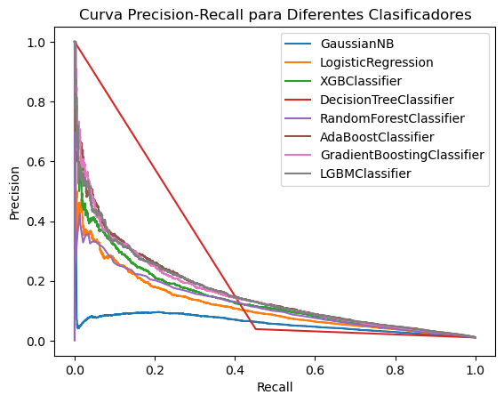

```
GaussianNB:
   Mejor F2-score: 0.206
   Mejor Threshold: 0.990

LogisticRegression:
   Mejor F2-score: 0.260
   Mejor Threshold: 0.525

XGBClassifier:
   Mejor F2-score: 0.288
   Mejor Threshold: 0.535

DecisionTreeClassifier:
   Mejor F2-score: 0.144
   Mejor Threshold: 0.000

RandomForestClassifier:
   Mejor F2-score: 0.284
   Mejor Threshold: 0.505

AdaBoostClassifier:
   Mejor F2-score: 0.263
   Mejor Threshold: 0.505

GradientBoostingClassifier:
   Mejor F2-score: 0.302
   Mejor Threshold: 0.495

LGBMClassifier:
   Mejor F2-score: 0.302
   Mejor Threshold: 0.545
```

```python
# Supongamos que ya tienes tus datos de entrenamiento y validación: X_train, X_val, y_train, y_val

# Define your thresholds
thresholds = np.linspace(0, 1, 100)  # You can adjust the range and number of thresholds

classifiers = [
    GaussianNB(),
    LogisticRegression(),
    XGBClassifier(),
    DecisionTreeClassifier(),
    RandomForestClassifier(),
    AdaBoostClassifier(),
    GradientBoostingClassifier(),
    LGBMClassifier()
]

# Inicializa una lista para almacenar los resultados de F2-score y thresholds
f2_scores = []
beta = 2  # Puedes ajustar este valor según tus preferencias

for classifier in classifiers:
    classifier_name = classifier.__class__.__name__

    # Crea un pipeline con el clasificador
    pipe = Pipeline(steps=[('classifier', classifier)])
    pipe.fit(X_train1, y_train1)

    # Obtén las probabilidades de las clases
    y_prob = pipe.predict_proba(X_val)[:, 1]

    # Inicializa listas para almacenar los resultados de F2-score para cada threshold
    f2_scores_classifier = []

    for threshold in thresholds:
        # Aplica el threshold a las predicciones
        y_pred = (y_prob > threshold).astype(int)

        # Calcula el F2-score
        f2 = fbeta_score(y_val, y_pred, beta=beta)
        f2_scores_classifier.append(f2)

    # Encuentra el mejor F2-score y su correspondiente threshold
    best_f2_score = max(f2_scores_classifier)
    best_threshold = thresholds[f2_scores_classifier.index(best_f2_score)]

    # Almacena los resultados
    f2_scores.append({
        'classifier': classifier_name,
        'best_f2_score': best_f2_score,
        'best_threshold': best_threshold
    })

    # Grafica la curva de precision-recall
    precision, recall, _ = precision_recall_curve(y_val, y_prob)
    plt.plot(recall, precision, label=classifier_name)

# Muestra la leyenda y etiquetas del gráfico
plt.legend()
plt.xlabel('Recall')
plt.ylabel('Precision')
plt.title('Curva Precision-Recall para Diferentes Clasificadores')
plt.show()

# Muestra el mejor F2-score y threshold para cada clasificador
for result in f2_scores:
    print(f"{result['classifier']}:")
    print(f"   Mejor F2-score: {result['best_f2_score']:.3f}")
    print(f"   Mejor Threshold: {result['best_threshold']:.3f}")
    print()
```

```python
classifiers = [
    GaussianNB(),
    LogisticRegression(),
    XGBClassifier(),
    DecisionTreeClassifier(),
    RandomForestClassifier(),
    AdaBoostClassifier(),
    GradientBoostingClassifier(),
    LGBMClassifier()
]

beta = 2
threshold = 0.525  # Nuevo umbral

for classifier in classifiers:
    pipe = Pipeline(steps=[('classifier', classifier)])
    pipe.fit(X_train1, y_train1)

    # Obtener las probabilidades de las clases
    y_prob = pipe.predict_proba(X_val)

    # Aplicar el nuevo umbral a las predicciones
    y_pred = (y_prob[:, 1] > threshold).astype(int)

    # Calcula el model score
    model_score = pipe.score(X_val, y_val)

    # Calcular f-beta score
    f_beta = fbeta_score(y_val, y_pred, beta=beta)


    print(f"{classifier.__class__.__name__}")
    print(f"Model Score: {model_score:.3f}")
    print(f"F-{beta} Score: {f_beta:.3f}")
    print(classification_report(y_val, y_pred))
    print()
```

[output not shown]

```
GaussianNB
Model Score: 0.840
F-2 Score: 0.170
              precision    recall  f1-score   support

           0       1.00      0.85      0.91    197860
           1       0.04      0.64      0.08      2140

    accuracy                           0.84    200000
   macro avg       0.52      0.74      0.50    200000
weighted avg       0.99      0.84      0.91    200000
```

[output not shown]

```
LogisticRegression
Model Score: 0.957
F-2 Score: 0.260
              precision    recall  f1-score   support

           0       0.99      0.97      0.98    197860
           1       0.11      0.38      0.18      2140

    accuracy                           0.96    200000
   macro avg       0.55      0.68      0.58    200000
weighted avg       0.98      0.96      0.97    200000


XGBClassifier
Model Score: 0.948
F-2 Score: 0.287
              precision    recall  f1-score   support

           0       0.99      0.96      0.98    197860
           1       0.11      0.49      0.18      2140

    accuracy                           0.95    200000
   macro avg       0.55      0.72      0.58    200000
weighted avg       0.98      0.95      0.97    200000


DecisionTreeClassifier
Model Score: 0.873
F-2 Score: 0.142
              precision    recall  f1-score   support

           0       0.99      0.88      0.93    197860
           1       0.04      0.45      0.07      2140

    accuracy                           0.87    200000
   macro avg       0.52      0.66      0.50    200000
weighted avg       0.98      0.87      0.92    200000
```

[output not shown]

```
RandomForestClassifier
Model Score: 0.965
F-2 Score: 0.276
              precision    recall  f1-score   support

           0       0.99      0.97      0.98    197860
           1       0.14      0.37      0.20      2140

    accuracy                           0.97    200000
   macro avg       0.56      0.67      0.59    200000
weighted avg       0.98      0.97      0.98    200000
```

[output not shown]

```
AdaBoostClassifier
Model Score: 0.954
F-2 Score: 0.004
              precision    recall  f1-score   support

           0       0.99      1.00      0.99    197860
           1       0.75      0.00      0.01      2140

    accuracy                           0.99    200000
   macro avg       0.87      0.50      0.50    200000
weighted avg       0.99      0.99      0.98    200000
```

[output not shown]

```
GradientBoostingClassifier
Model Score: 0.961
F-2 Score: 0.299
              precision    recall  f1-score   support

           0       0.99      0.97      0.98    197860
           1       0.14      0.43      0.21      2140

    accuracy                           0.96    200000
   macro avg       0.56      0.70      0.59    200000
weighted avg       0.98      0.96      0.97    200000


[LightGBM] [Info] Number of positive: 6683, number of negative: 33415
[LightGBM] [Info] Auto-choosing col-wise multi-threading, the overhead of testing was 0.009008 seconds.
You can set `force_col_wise=true` to remove the overhead.
[LightGBM] [Info] Total Bins 3762
[LightGBM] [Info] Number of data points in the train set: 40098, number of used features: 40
[LightGBM] [Info] [binary:BoostFromScore]: pavg=0.166667 -> initscore=-1.609438
[LightGBM] [Info] Start training from score -1.609438
```

[output not shown]

```
LGBMClassifier
Model Score: 0.954
F-2 Score: 0.300
              precision    recall  f1-score   support

           0       0.99      0.96      0.98    197860
           1       0.12      0.47      0.20      2140

    accuracy                           0.96    200000
   macro avg       0.56      0.72      0.59    200000
weighted avg       0.98      0.96      0.97    200000
```

## Hacemos undersampling

Una vez confirmado que elegimos el model LGBM, volvemos al train0 para renombrarlos como train2 haciendo un undersampling del total de la muestra. Ahora elegimos cual la mejor estrategia de remuestreo para entrenar el modelo. Lo hacemos mediante validación cruzada de x_train0 e y_train0, los cuales, una vez tengamos el valor elegido, serán balanceados de tal forma que los pasaremos a x_train2 e y_train2.

```python
from sklearn.model_selection import train_test_split

X_train3, X_test3, y_train3, y_test3 = train_test_split(X_train0, y_train0, test_size=0.2, stratify=y_train0, random_state=69)
```

```python
import numpy as np
from sklearn.model_selection import train_test_split
from sklearn.metrics import fbeta_score
from imblearn.under_sampling import RandomUnderSampler
from sklearn.ensemble import RandomForestClassifier

# Supongamos que X_train3 es tu conjunto de entrenamiento y X_val es tu conjunto de validación

# 1. Divide el conjunto de entrenamiento en entrenamiento y prueba
X_train, X_val, y_train, y_val = train_test_split(X_train0, y_train0, test_size=0.2, random_state=42)

# 2. Define las tasas de undersampling que deseas probar (de 0.05 en 0.05)
undersampling_rates = np.arange(0.05, 1.0, 0.05)

# 3. Itera sobre las tasas de undersampling
for rate in undersampling_rates:
    # 4. Aplica RandomUnderSampler con la tasa actual
    rus = RandomUnderSampler(sampling_strategy=rate, random_state=42)
    X_resampled, y_resampled = rus.fit_resample(X_train, y_train)

    # 5. Entrena un clasificador (por ejemplo, RandomForest) con los datos undersampled
    clf = RandomForestClassifier(random_state=69)
    clf.fit(X_resampled, y_resampled)

    # 6. Realiza predicciones en el conjunto de validación
    y_pred = clf.predict(X_val)

    # 7. Calcula y muestra el F2-score
    f2 = fbeta_score(y_val, y_pred, beta=2)
    print(f"Undersampling Rate: {rate:.2f} - F2 Score on Validation Set: {f2:.4f}")
```

[output not shown]

```
Undersampling Rate: 0.05 - F2 Score on Validation Set: 0.0996
```

[output not shown]

```
Undersampling Rate: 0.10 - F2 Score on Validation Set: 0.2133
```

[output not shown]

```
Undersampling Rate: 0.15 - F2 Score on Validation Set: 0.2668
```

[output not shown]

```
Undersampling Rate: 0.20 - F2 Score on Validation Set: 0.2829
```

[output not shown]

```
Undersampling Rate: 0.25 - F2 Score on Validation Set: 0.2767
```

[output not shown]

```
Undersampling Rate: 0.30 - F2 Score on Validation Set: 0.2686
```

[output not shown]

```
Undersampling Rate: 0.35 - F2 Score on Validation Set: 0.2596
```

[output not shown]

```
Undersampling Rate: 0.40 - F2 Score on Validation Set: 0.2515
```

[output not shown]

```
Undersampling Rate: 0.45 - F2 Score on Validation Set: 0.2383
```

[output not shown]

```
Undersampling Rate: 0.50 - F2 Score on Validation Set: 0.2322
```

[output not shown]

```
Undersampling Rate: 0.55 - F2 Score on Validation Set: 0.2210
```

[output not shown]

```
Undersampling Rate: 0.60 - F2 Score on Validation Set: 0.2148
```

[output not shown]

```
Undersampling Rate: 0.65 - F2 Score on Validation Set: 0.2079
```

[output not shown]

```
Undersampling Rate: 0.70 - F2 Score on Validation Set: 0.2019
```

[output not shown]

```
Undersampling Rate: 0.75 - F2 Score on Validation Set: 0.1937
```

[output not shown]

```
Undersampling Rate: 0.80 - F2 Score on Validation Set: 0.1870
```

[output not shown]

```
Undersampling Rate: 0.85 - F2 Score on Validation Set: 0.1825
```

[output not shown]

```
Undersampling Rate: 0.90 - F2 Score on Validation Set: 0.1763
```

[output not shown]

```
Undersampling Rate: 0.95 - F2 Score on Validation Set: 0.1727
```

[output not shown]

```
[LightGBM] [Info] Number of positive: 7110, number of negative: 71100
[LightGBM] [Info] Auto-choosing col-wise multi-threading, the overhead of testing was 0.021718 seconds.
You can set `force_col_wise=true` to remove the overhead.
[LightGBM] [Info] Total Bins 3762
[LightGBM] [Info] Number of data points in the train set: 78210, number of used features: 40
[LightGBM] [Info] [binary:BoostFromScore]: pavg=0.090909 -> initscore=-2.302585
[LightGBM] [Info] Start training from score -2.302585
Undersampling Rate: 0.100 - F2 Score on Validation Set: 0.2812
```

[output not shown]

```
[LightGBM] [Info] Number of positive: 7110, number of negative: 64636
[LightGBM] [Info] Auto-choosing col-wise multi-threading, the overhead of testing was 0.023850 seconds.
You can set `force_col_wise=true` to remove the overhead.
[LightGBM] [Info] Total Bins 3761
[LightGBM] [Info] Number of data points in the train set: 71746, number of used features: 40
[LightGBM] [Info] [binary:BoostFromScore]: pavg=0.099100 -> initscore=-2.207269
[LightGBM] [Info] Start training from score -2.207269
Undersampling Rate: 0.110 - F2 Score on Validation Set: 0.2913
```

[output not shown]

```
[LightGBM] [Info] Number of positive: 7110, number of negative: 59250
[LightGBM] [Info] Auto-choosing col-wise multi-threading, the overhead of testing was 0.016882 seconds.
You can set `force_col_wise=true` to remove the overhead.
[LightGBM] [Info] Total Bins 3761
[LightGBM] [Info] Number of data points in the train set: 66360, number of used features: 40
[LightGBM] [Info] [binary:BoostFromScore]: pavg=0.107143 -> initscore=-2.120264
[LightGBM] [Info] Start training from score -2.120264
Undersampling Rate: 0.120 - F2 Score on Validation Set: 0.2904
```

[output not shown]

```
[LightGBM] [Info] Number of positive: 7110, number of negative: 54692
[LightGBM] [Info] Auto-choosing col-wise multi-threading, the overhead of testing was 0.016099 seconds.
You can set `force_col_wise=true` to remove the overhead.
[LightGBM] [Info] Total Bins 3761
[LightGBM] [Info] Number of data points in the train set: 61802, number of used features: 40
[LightGBM] [Info] [binary:BoostFromScore]: pavg=0.115045 -> initscore=-2.040215
[LightGBM] [Info] Start training from score -2.040215
Undersampling Rate: 0.130 - F2 Score on Validation Set: 0.2966
```

[output not shown]

```
[LightGBM] [Info] Number of positive: 7110, number of negative: 50785
[LightGBM] [Info] Auto-choosing col-wise multi-threading, the overhead of testing was 0.015747 seconds.
You can set `force_col_wise=true` to remove the overhead.
[LightGBM] [Info] Total Bins 3761
[LightGBM] [Info] Number of data points in the train set: 57895, number of used features: 40
[LightGBM] [Info] [binary:BoostFromScore]: pavg=0.122809 -> initscore=-1.966099
[LightGBM] [Info] Start training from score -1.966099
Undersampling Rate: 0.140 - F2 Score on Validation Set: 0.2944
```

[output not shown]

```
[LightGBM] [Info] Number of positive: 7110, number of negative: 47400
[LightGBM] [Info] Auto-choosing col-wise multi-threading, the overhead of testing was 0.017244 seconds.
You can set `force_col_wise=true` to remove the overhead.
[LightGBM] [Info] Total Bins 3761
[LightGBM] [Info] Number of data points in the train set: 54510, number of used features: 40
[LightGBM] [Info] [binary:BoostFromScore]: pavg=0.130435 -> initscore=-1.897120
[LightGBM] [Info] Start training from score -1.897120
Undersampling Rate: 0.150 - F2 Score on Validation Set: 0.3015
```

[output not shown]

```
[LightGBM] [Info] Number of positive: 7110, number of negative: 44437
[LightGBM] [Info] Auto-choosing col-wise multi-threading, the overhead of testing was 0.015901 seconds.
You can set `force_col_wise=true` to remove the overhead.
[LightGBM] [Info] Total Bins 3761
[LightGBM] [Info] Number of data points in the train set: 51547, number of used features: 40
[LightGBM] [Info] [binary:BoostFromScore]: pavg=0.137932 -> initscore=-1.832570
[LightGBM] [Info] Start training from score -1.832570
Undersampling Rate: 0.160 - F2 Score on Validation Set: 0.3019
```

[output not shown]

```
[LightGBM] [Info] Number of positive: 7110, number of negative: 41823
[LightGBM] [Info] Auto-choosing col-wise multi-threading, the overhead of testing was 0.014431 seconds.
You can set `force_col_wise=true` to remove the overhead.
[LightGBM] [Info] Total Bins 3761
[LightGBM] [Info] Number of data points in the train set: 48933, number of used features: 40
[LightGBM] [Info] [binary:BoostFromScore]: pavg=0.145301 -> initscore=-1.771944
[LightGBM] [Info] Start training from score -1.771944
Undersampling Rate: 0.170 - F2 Score on Validation Set: 0.3014
```

[output not shown]

```
[LightGBM] [Info] Number of positive: 7110, number of negative: 39500
[LightGBM] [Info] Auto-choosing col-wise multi-threading, the overhead of testing was 0.014570 seconds.
You can set `force_col_wise=true` to remove the overhead.
[LightGBM] [Info] Total Bins 3761
[LightGBM] [Info] Number of data points in the train set: 46610, number of used features: 40
[LightGBM] [Info] [binary:BoostFromScore]: pavg=0.152542 -> initscore=-1.714798
[LightGBM] [Info] Start training from score -1.714798
Undersampling Rate: 0.180 - F2 Score on Validation Set: 0.2991
```

[output not shown]

```
[LightGBM] [Info] Number of positive: 7110, number of negative: 37421
[LightGBM] [Info] Auto-choosing col-wise multi-threading, the overhead of testing was 0.012806 seconds.
You can set `force_col_wise=true` to remove the overhead.
[LightGBM] [Info] Total Bins 3761
[LightGBM] [Info] Number of data points in the train set: 44531, number of used features: 40
[LightGBM] [Info] [binary:BoostFromScore]: pavg=0.159664 -> initscore=-1.660730
[LightGBM] [Info] Start training from score -1.660730
Undersampling Rate: 0.190 - F2 Score on Validation Set: 0.2935
```

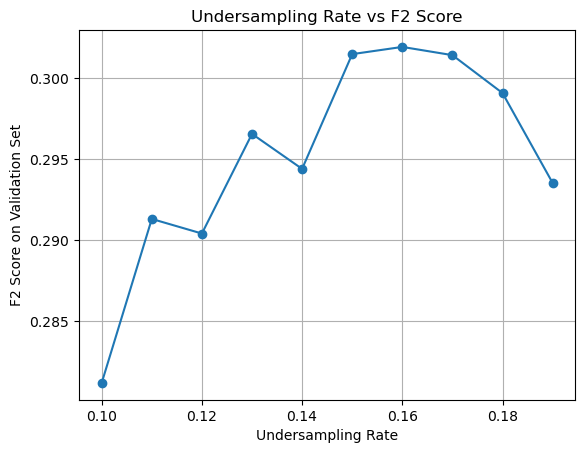

```python
# 1. Divide el conjunto de entrenamiento en entrenamiento y prueba
X_train, X_val, y_train, y_val = train_test_split(X_train0, y_train0, test_size=0.2, random_state=42)

# 2. Define las tasas de undersampling que deseas probar (de 0.001 en 0.001 entre 0.1 y 0.2)
undersampling_rates = np.arange(0.10, 0.20, 0.01)

# Almacena los resultados
undersampling_results = []
f2_scores = []

# 3. Itera sobre las tasas de undersampling
for rate in undersampling_rates:
    # 4. Aplica RandomUnderSampler con la tasa actual
    rus = RandomUnderSampler(sampling_strategy=rate, random_state=42)
    X_resampled, y_resampled = rus.fit_resample(X_train, y_train)

    # 5. Entrena un clasificador (por ejemplo, LGBMClassifier) con los datos undersampled
    clf = LGBMClassifier(random_state=69)
    clf.fit(X_resampled, y_resampled)

    # 6. Realiza predicciones en el conjunto de validación
    y_pred = clf.predict(X_val)

    # 7. Calcula y almacena el F2-score
    f2 = fbeta_score(y_val, y_pred, beta=2)
    undersampling_results.append(rate)
    f2_scores.append(f2)
    print(f"Undersampling Rate: {rate:.3f} - F2 Score on Validation Set: {f2:.4f}")

# Grafica los resultados
plt.plot(undersampling_results, f2_scores, marker='o')
plt.xlabel('Undersampling Rate')
plt.ylabel('F2 Score on Validation Set')
plt.title('Undersampling Rate vs F2 Score')
plt.grid(True)
plt.show()
```

Hacemos undersampling con 0.16 como estrategia de remuestreo. De esta forma, optimizamos el F2-Score, que es la métrica en la que estamos fijando nuestra atención. Como hemos comprobado a la hora de elaborar el modelo, cuanto mayor sea el sampling strategy a partir de 0.16, a pesar de que la F2-Score decrece, la captación de verdaderos positivos aumenta. Pero como la investigación de cada caso también tiene un coste y, utilizando la métrica F2Score ya estamos priorizando el recall sobre la precisión, decidimos quedarnos aquí. De otra forma, la cantidad de falsos positivos sería muy grande en comparación con los verdaderos positivos que recogeríamos.

```python
# Para reducir tiempos de computación a la hora de ejecutar un problema con un millón de instancias, y para elegir el modelo
# a utilizar, realizamos undersampling. Ahora el dataset se nos queda en un 60% de entrenamiento que estará rebalanceado,
# y una validación y test que permanecen vírgenes.
# Siempre utilizamos el mismo random_state para los splits
from imblearn.under_sampling import RandomUnderSampler

# Definir el undersampler con la proporción deseada
undersampler = RandomUnderSampler(sampling_strategy=0.16, random_state=69)

# Aplicar undersampling a X_train e y_train
X_train2, y_train2 = undersampler.fit_resample(X_train0, y_train0)

# Ver las formas antes y después del undersampling
print("Antes del undersampling - X_train:", X_train1.shape, "y_train:", y_train1.shape)
print("Después del undersampling - X_train_resampled:", X_train2.shape, "y_train_resampled:", y_train2.shape)
```

```
Antes del undersampling - X_train: (40098, 40) y_train: (40098, 1)
Después del undersampling - X_train_resampled: (63966, 40) y_train_resampled: (63966, 1)
```

## Buscamos hiperparámetros con LGBMClassifier

A la hora de buscar los hiperparámetros, como scorer objetivo hemos elegido que se maximice el f2score, lo que hará que el modelo optimice esta métrica, que es especialmente sensible con la búsqueda de positivos en detrimento de la búsqueda de negativos y de evitar falsos negativos.

```python
# Definir el modelo LGBMClassifier
lgbm_model = LGBMClassifier(random_state=69)

# Definir los parámetros a ajustar
param_grid = {
    'n_estimators': [50, 100, 200],
    'learning_rate': [0.01, 0.1, 0.2],
    'max_depth': [5, 10, 15],
    'subsample': [0.8, 1.0],
    'colsample_bytree': [0.8, 1.0]
}

# Definir la métrica a optimizar (F2-score)
scorer = make_scorer(fbeta_score, beta=2)

# Inicializar GridSearchCV
grid_search = GridSearchCV(estimator=lgbm_model, param_grid=param_grid, scoring=scorer, cv=3)

# Ajustar el modelo
grid_search.fit(X_train2, y_train2)

# Obtener el mejor modelo
best_lgbm_model = grid_search.best_estimator_

# Imprimir los mejores hiperparámetros
print("Mejores hiperparámetros encontrados:")
print(grid_search.best_params_)

# Imprimir el F2-score del mejor modelo en los datos de entrenamiento
y_pred = best_lgbm_model.predict(X_test)
f2_score = fbeta_score(y_test, y_pred, beta=2)

# Imprimir el resultado
print(f"F2-score en datos de prueba: {f2_score:.3f}")
print(classification_report(y_test, y_pred))
```

[output not shown]

[output not shown]

[output not shown]

[output not shown]

[output not shown]

[output not shown]

[output not shown]

[output not shown]

[output not shown]

[output not shown]

[output not shown]

[output not shown]

[output not shown]

[output not shown]

[output not shown]

[output not shown]

[output not shown]

[output not shown]

[output not shown]

[output not shown]

[output not shown]

[output not shown]

[output not shown]

[output not shown]

[output not shown]

[output not shown]

[output not shown]

[output not shown]

[output not shown]

[output not shown]

[output not shown]

[output not shown]

[output not shown]

[output not shown]

[output not shown]

[output not shown]

[output not shown]

[output not shown]

[output not shown]

[output not shown]

[output not shown]

[output not shown]

[output not shown]

[output not shown]

[output not shown]

[output not shown]

[output not shown]

[output not shown]

[output not shown]

[output not shown]

[output not shown]

[output not shown]

[output not shown]

[output not shown]

[output not shown]

[output not shown]

[output not shown]

[output not shown]

[output not shown]

[output not shown]

[output not shown]

[output not shown]

[output not shown]

[output not shown]

[output not shown]

[output not shown]

[output not shown]

[output not shown]

[output not shown]

[output not shown]

[output not shown]

[output not shown]

[output not shown]

[output not shown]

[output not shown]

[output not shown]

[output not shown]

[output not shown]

[output not shown]

[output not shown]

[output not shown]

[output not shown]

[output not shown]

[output not shown]

[output not shown]

[output not shown]

[output not shown]

[output not shown]

[output not shown]

[output not shown]

[output not shown]

[output not shown]

[output not shown]

[output not shown]

[output not shown]

[output not shown]

[output not shown]

[output not shown]

[output not shown]

[output not shown]

[output not shown]

[output not shown]

[output not shown]

[output not shown]

[output not shown]

[output not shown]

[output not shown]

[output not shown]

[output not shown]

[output not shown]

[output not shown]

[output not shown]

[output not shown]

[output not shown]

[output not shown]

[output not shown]

[output not shown]

[output not shown]

[output not shown]

[output not shown]

[output not shown]

[output not shown]

[output not shown]

[output cut: 10 more lines]

[output not shown]

[output not shown]

[output not shown]

[output cut: 8 more lines]

[output not shown]

[output not shown]

[output not shown]

[output not shown]

[output not shown]

[output cut: 10 more lines]

[output not shown]

[output not shown]

[output not shown]

[output cut: 8 more lines]

[output not shown]

[output not shown]

[output not shown]

[output not shown]

[output not shown]

[output cut: 90 more lines]

[output not shown]

[output not shown]

[output not shown]

[output cut: 93 more lines]

[output not shown]

[output not shown]

[output not shown]

[output cut: 88 more lines]

[output not shown]

[output not shown]

[output not shown]

[output cut: 91 more lines]

[output not shown]

[output not shown]

[output not shown]

[output cut: 93 more lines]

[output not shown]

[output not shown]

[output not shown]

[output cut: 88 more lines]

[output not shown]

[output not shown]

[output not shown]

[output not shown]

[output not shown]

[output not shown]

[output not shown]

[output not shown]

[output not shown]

[output not shown]

[output not shown]

[output not shown]

[output not shown]

[output not shown]

[output not shown]

[output not shown]

[output not shown]

[output not shown]

[output not shown]

[output not shown]

[output not shown]

[output not shown]

[output not shown]

[output not shown]

[output not shown]

[output not shown]

[output not shown]

[output not shown]

[output not shown]

[output not shown]

[output not shown]

[output not shown]

[output not shown]

[output not shown]

[output not shown]

[output not shown]

[output not shown]

[output not shown]

[output not shown]

[output not shown]

[output not shown]

[output not shown]

[output not shown]

[output not shown]

[output not shown]

[output not shown]

[output not shown]

[output not shown]

[output not shown]

[output not shown]

[output not shown]

[output not shown]

[output not shown]

[output not shown]

[output not shown]

[output not shown]

[output not shown]

[output not shown]

[output not shown]

[output not shown]

[output not shown]

[output not shown]

[output not shown]

[output not shown]

[output not shown]

[output not shown]

[output not shown]

[output not shown]

[output not shown]

[output not shown]

[output not shown]

[output not shown]

[output not shown]

[output not shown]

[output not shown]

[output not shown]

[output not shown]

[output not shown]

[output not shown]

[output not shown]

[output not shown]

[output not shown]

[output not shown]

[output not shown]

[output not shown]

[output not shown]

[output not shown]

[output cut: 27 more lines]

[output not shown]

[output not shown]

[output not shown]

[output cut: 17 more lines]

[output not shown]